# Practical Machine Learning: Prediction Assignment - Writeup

A. U.

2015-08-14

## Executive Summary

The goal of this project is to predict the manner (correctly and incorrectly in 5 different ways) in which they did the exercise (barbell lifts). This is the “classe” variable in the training set, the whole of which we explore first. After removing irrelevant features and noise from the data, we proceed to build 7 models. Using cross validation against a held-out portion of the training data, we determine the out of sample error by measuring the effective accuracy. Finally, we use the best prediction model (random forests) to predict 20 different test cases and perform a second validation.

## Data loading and preprocessing

We first load the data provided at http://groupware.les.inf.puc-rio.br/har. The R code provided expects to find the CSV files in its current working directory.

Unfortunately, there was no clear codebook available (apart from indirect hints in the paper on the same website), which is why we will have to some extra data exploration before we can start building models.

```r
library(lubridate)
pml.training <- read.csv("pml-training.csv", row.names=1, na.strings=c("NA", "#DIV/0!", ""))
pml.testing <- read.csv("pml-testing.csv", row.names=1, na.strings=c("NA", "#DIV/0!", ""))
pml.training$cvtd_timestamp <- mdy_hm(pml.training$cvtd_timestamp)
pml.testing$cvtd_timestamp <- mdy_hm(pml.testing$cvtd_timestamp)
```

A first look at the data reveals that 100 variables in the testing set only contain NAs.

Since we ultimately intend to predict cases from the testing set provided, we eliminate all potential predictor columns in the training and testing set which only contain NAs or other unusable values in the testing set.

```r
set.seed(2407)
rmcols1 <- colnames(pml.testing[, colSums(!is.na(pml.testing)) != nrow(pml.testing)])
rmcols1 <- append(rmcols1, colnames(pml.training[,c(2:3,5)]))
df1.train <- pml.training[,-which(names(pml.training) %in% rmcols1)]
df1.test  <- pml.testing[,-which(names(pml.testing) %in% rmcols1)]
summary(df1.train)
```

```
##     user_name    cvtd_timestamp                  num_window
##  adelmo  :3892   Min.   :2011-01-19 11:21:49   Min.   :  1.0
##  carlitos:3112   1st Qu.:2011-02-12 13:34:00   1st Qu.:222.0
##  charles :3536   Median :2011-02-12 14:58:00   Median :424.0
##  eurico  :3070   Mean   :2019-04-07 09:52:55   Mean   :430.6
##  jeremy  :3402   3rd Qu.:2011-05-12 14:23:00   3rd Qu.:644.0
##  pedro   :2610   Max.   :2062-10-23 14:10:17   Max.   :864.0
##    roll_belt        pitch_belt          yaw_belt       total_accel_belt
##  Min.   :-28.90   Min.   :-55.8000   Min.   :-180.00   Min.   : 0.00
##  1st Qu.:  1.10   1st Qu.:  1.7600   1st Qu.: -88.30   1st Qu.: 3.00
##  Median :113.00   Median :  5.2800   Median : -13.00   Median :17.00
##  Mean   : 64.41   Mean   :  0.3053   Mean   : -11.21   Mean   :11.31
##  3rd Qu.:123.00   3rd Qu.: 14.9000   3rd Qu.:  12.90   3rd Qu.:18.00
##  Max.   :162.00   Max.   : 60.3000   Max.   : 179.00   Max.   :29.00
##   gyros_belt_x        gyros_belt_y       gyros_belt_z
##  Min.   :-1.040000   Min.   :-0.64000   Min.   :-1.4600
##  1st Qu.:-0.030000   1st Qu.: 0.00000   1st Qu.:-0.2000
##  Median : 0.030000   Median : 0.02000   Median :-0.1000
##  Mean   :-0.005592   Mean   : 0.03959   Mean   :-0.1305
##  3rd Qu.: 0.110000   3rd Qu.: 0.11000   3rd Qu.:-0.0200
##  Max.   : 2.220000   Max.   : 0.64000   Max.   : 1.6200
##   accel_belt_x       accel_belt_y     accel_belt_z     magnet_belt_x
##  Min.   :-120.000   Min.   :-69.00   Min.   :-275.00   Min.   :-52.0
##  1st Qu.: -21.000   1st Qu.:  3.00   1st Qu.:-162.00   1st Qu.:  9.0
##  Median : -15.000   Median : 35.00   Median :-152.00   Median : 35.0
##  Mean   :  -5.595   Mean   : 30.15   Mean   : -72.59   Mean   : 55.6
##  3rd Qu.:  -5.000   3rd Qu.: 61.00   3rd Qu.:  27.00   3rd Qu.: 59.0
##  Max.   :  85.000   Max.   :164.00   Max.   : 105.00   Max.   :485.0
##  magnet_belt_y   magnet_belt_z       roll_arm         pitch_arm
##  Min.   :354.0   Min.   :-623.0   Min.   :-180.00   Min.   :-88.800
##  1st Qu.:581.0   1st Qu.:-375.0   1st Qu.: -31.77   1st Qu.:-25.900
##  Median :601.0   Median :-320.0   Median :   0.00   Median :  0.000
##  Mean   :593.7   Mean   :-345.5   Mean   :  17.83   Mean   : -4.612
##  3rd Qu.:610.0   3rd Qu.:-306.0   3rd Qu.:  77.30   3rd Qu.: 11.200
##  Max.   :673.0   Max.   : 293.0   Max.   : 180.00   Max.   : 88.500
##     yaw_arm          total_accel_arm  gyros_arm_x        gyros_arm_y
##  Min.   :-180.0000   Min.   : 1.00   Min.   :-6.37000   Min.   :-3.4400
##  1st Qu.: -43.1000   1st Qu.:17.00   1st Qu.:-1.33000   1st Qu.:-0.8000
##  Median :   0.0000   Median :27.00   Median : 0.08000   Median :-0.2400
##  Mean   :  -0.6188   Mean   :25.51   Mean   : 0.04277   Mean   :-0.2571
```

[output cut: 57 more lines]

```
##  Max.   :311.00000   Max.   :231.0000   Max.   : 477.00   Max.   : 923.0
##  accel_forearm_z   magnet_forearm_x  magnet_forearm_y magnet_forearm_z
##  Min.   :-446.00   Min.   :-1280.0   Min.   :-896.0   Min.   :-973.0
##  1st Qu.:-182.00   1st Qu.: -616.0   1st Qu.:   2.0   1st Qu.: 191.0
##  Median : -39.00   Median : -378.0   Median : 591.0   Median : 511.0
##  Mean   : -55.29   Mean   : -312.6   Mean   : 380.1   Mean   : 393.6
##  3rd Qu.:  26.00   3rd Qu.:  -73.0   3rd Qu.: 737.0   3rd Qu.: 653.0
##  Max.   : 291.00   Max.   :  672.0   Max.   :1480.0   Max.   :1090.0
##  classe
##  A:5580
##  B:3797
##  C:3422
##  D:3216
##  E:3607
##
```

Upon inspection of the variable summary it becomes obvious that the predictors are not well centered and that the scaling of the measurements also appears to be a problem. We will have to address these two issues in the preprocessing of the model training later on.

In addition, we convert the predictors that were imported as integers into numeric data types for later correlation analysis.

```r
intcols <- as.vector(sapply(df1.train,class)) %in% "integer"
df1.train[,intcols] <- as.data.frame(sapply(df1.train[,intcols],as.numeric))
intcols <- as.vector(sapply(df1.test,class)) %in% "integer"
df1.test[,intcols] <- as.data.frame(sapply(df1.test[,intcols],as.numeric))
```

Let’s explore the available numeric features by plotting them against the outcome class.

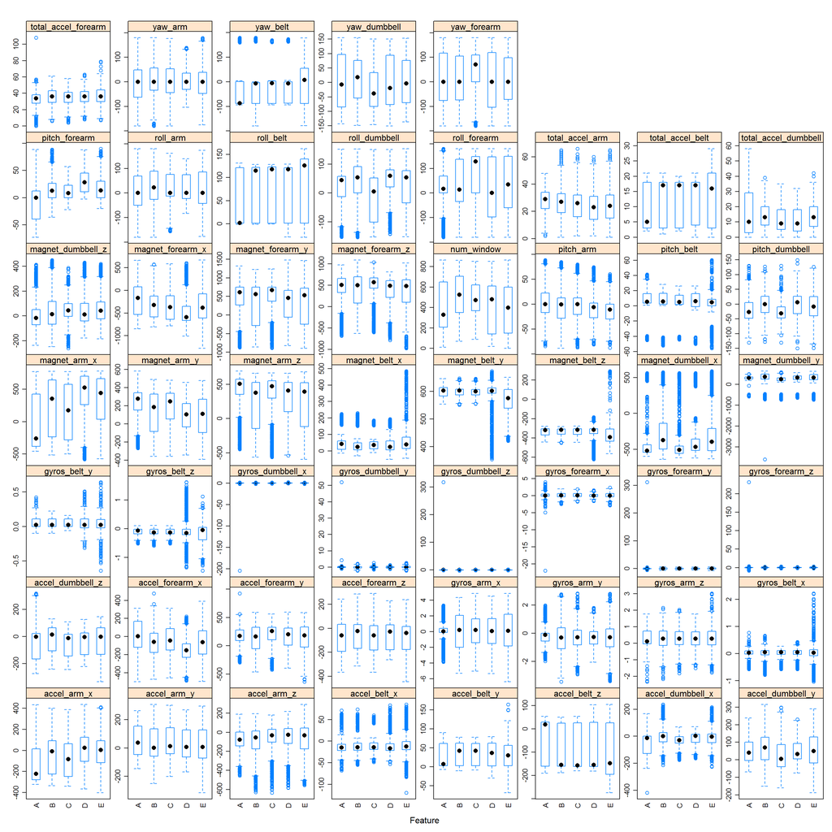

```r
library(caret)
numcols <- as.vector(sapply(df1.train,class)) %in% "numeric"
featurePlot(x = df1.train[, numcols],
            y = df1.train$classe,
            plot = "box",
            ## Pass in options to bwplot()
            scales = list(y = list(relation="free"),
                          x = list(rot = 90))
                        )
```

As can be gathered from the above plot, some of the numeric predictors have little variance while others seem to have captured some outliers around an otherwise centered median value. Due to this, we will check whether the predictors are normally distributed.

To ensure optimal performance of our model building efforts, we losely follow the guide provided by the caret package maintainers at https://topepo.github.io/caret/preprocess.html and apply some of their preprocessing suggestions. Let’s check for zero- or near-zero-variance predictors first and remove columns with little predictive value.

```r
library(caret)
set.seed(2407)
outvar <- ncol(df1.train)
nzv <- nearZeroVar(df1.train[,-outvar], saveMetrics=TRUE)
nzv[nzv$nzv,]
```

```
## [1] freqRatio     percentUnique zeroVar       nzv
## <0 rows> (or 0-length row.names)
```

```r
rmcols2 <- rownames(nzv[nzv$nzv,])
if(length(rmcols2) > 0) {
  df1.train <- df1.train[,-which(names(df1.train) %in% rmcols2)]
  df1.test <- df1.test[,-which(names(df1.test) %in% rmcols2)]
  }
```

We also check the data for correlated predictors which can potentially be removed. We set the threshold for this to 90% correlation.

```r
numcols <- as.vector(sapply(df1.train,class)) %in% "numeric"
descrCor <-  cor(df1.train[,numcols])
highlyCorDescr <- findCorrelation(descrCor, cutoff = .90)
rmcols3 <- names(df1.train[,highlyCorDescr])
rmcols3
```

```
## [1] "accel_belt_x"     "cvtd_timestamp"   "gyros_belt_z"
## [4] "gyros_belt_y"     "yaw_dumbbell"     "gyros_dumbbell_x"
## [7] "yaw_arm"
```

```r
if(length(rmcols3) > 0) {
  df1.train <- df1.train[,-which(names(df1.train) %in% rmcols3)]
  df1.test <- df1.test[,-which(names(df1.test) %in% rmcols3)]
  }
```

```r
set.seed(2407)
df1.train.5k <- df1.train[sample(nrow(df1.train),replace=F,size=5000),]
outvar <- ncol(df1.train)
predcols <- as.vector(sapply(df1.train.5k,class)) %in% "numeric"
swtest <- sapply(df1.train.5k[,predcols], shapiro.test)
pvalmax <- max(as.numeric(swtest[2,]))
#pvalmax <- 0
```

Finally, we split the original training data into two sets, one for actually training our model and the other for testing. The split ratio is 60:40 for training:testing. To avoid naming confusion, we also put the original PML-testing set into a separate data frame for final validation of our models by predicting the outcome and submitting it to the server for verification.

```r
library(caret)
set.seed(2407)
inTrain <- createDataPartition(df1.train$classe, p=0.6, list=FALSE)
df2.train <- df1.train[inTrain,]
df2.test  <- df1.train[-inTrain,]
df2.val   <- df1.test
```

## Model training

We will train a total of 7 models using very commonly used and recommended methods: Classification trees, neural networks, supporting vector machines, boosted trees, linear discriminant model, random forests and k-nearest-neighbors.

As discussed above, the features in this dataset appear to have some issues regarding centering and scaling, which can easily be fixed by adding the appropriate preprocessing parameters when training the models. We also considered performing a PCA, but decided against it due to the much reduced interpretability of the resulting models.

```r
library(caret)
set.seed(2407)
if (file.exists("fitrpart.Rds")) {
  fit.rpart <- readRDS("fitrpart.Rds")
} else {
  fit.rpart <- train(classe ~ .
                 ,data = df2.train
                 ,preProcess = c("center", "scale")
                 ,method = "rpart"
                 ,na.action = "na.omit"
                 )
  saveRDS(fit.rpart, file="fitrpart.Rds")
}

if (file.exists("fitnnet.Rds")) {
  fit.nnet <- readRDS("fitnnet.Rds")
} else {
  fit.nnet <- train(classe ~ .
                 ,data = df2.train
                 ,preProcess = c("center", "scale")
                 ,method = "nnet"
                 ,na.action = "na.omit"
                 ,trace = FALSE
                 )
  saveRDS(fit.nnet, file="fitnnet.Rds")
}

if (file.exists("fitsvm.Rds")) {
  fit.svm <- readRDS("fitsvm.Rds")
} else {
  fit.svm <- train(classe ~ .
                 ,data = df2.train
                 ,preProcess = c("center", "scale")
                 ,method = "svmLinear"
                 ,na.action = "na.omit"
                 )
  saveRDS(fit.svm, file="fitsvm.Rds")
}

if (file.exists("fitgbm.Rds")) {
  fit.gbm <- readRDS("fitgbm.Rds")
} else {
  fit.gbm <- train(classe ~ .
                 ,data = df2.train
                 ,preProcess = c("center", "scale")
                 ,method = "gbm"
                 ,na.action = "na.omit"
                 ,verbose = FALSE
                 )
  saveRDS(fit.gbm, file="fitgbm.Rds")
}

if (file.exists("fitlda.Rds")) {
  fit.lda <- readRDS("fitlda.Rds")
} else {
  fit.lda <- train(classe ~ .
                 ,data = df2.train
                 ,preProcess = c("center", "scale")
                 ,method = "lda"
                 ,na.action = "na.omit"
                 )
  saveRDS(fit.lda, file="fitlda.Rds")
}

if (file.exists("fitrf.Rds")) {
  fit.rf <- readRDS("fitrf.Rds")
} else {
  fit.rf <- train(classe ~ .
                 ,data = df2.train
                 ,preProcess = c("center", "scale")
                 ,method = "rf"
                 ,na.action = "na.omit"
                 )
  saveRDS(fit.rf, file="fitrf.Rds")
}

if (file.exists("fitknn.Rds")) {
  fit.knn <- readRDS("fitknn.Rds")
} else {
  fit.knn <- train(classe ~ .
                 ,data = df2.train
                 ,preProcess = c("center", "scale")
                 ,method = "knn"
                 ,na.action = "na.omit"
                 )
  saveRDS(fit.knn, file="fitknn.Rds")
}
```

It is noteworthy that the training time differs quite considerably between the methods, with random forests and neural networks taking the longest by far. This also is the reason for the caching we perform using loadRDS and saveRDS to save time during the compilation of this report.

## Model evaluation

To evaluate the models we compare their predictions with the data from the held out test data we put aside earlier on (40% of the original training data). Since the outcome is a factor variable, we will be using the accuracy as the benchmarking metric.

```r
library(caret)
set.seed(2407)
cm.rpart <- confusionMatrix(predict(fit.rpart, df2.test), df2.test$classe)
cm.nnet <-  confusionMatrix(predict(fit.nnet,  df2.test), df2.test$classe)
cm.svm <-   confusionMatrix(predict(fit.svm,   df2.test), df2.test$classe)
cm.gbm <-   confusionMatrix(predict(fit.gbm,   df2.test), df2.test$classe)
cm.lda <-   confusionMatrix(predict(fit.lda,   df2.test), df2.test$classe)
cm.rf <-    confusionMatrix(predict(fit.rf,    df2.test), df2.test$classe)
cm.knn <-   confusionMatrix(predict(fit.knn,   df2.test), df2.test$classe)
```

To summarize the results of our model building efforts, we compile the method and its accuracy into a small plot.

```r
results <- as.data.frame(c(fit.rpart$method
                         , fit.nnet$method
                         , fit.svm$method
                         , fit.gbm$method
                         , fit.lda$method
                         , fit.rf$method
                         , fit.knn$method
                           ))
results$acc <-           (c(cm.rpart$overall[1]
                          , cm.nnet$overall[1]
                          , cm.svm$overall[1]
                          , cm.gbm$overall[1]
                          , cm.lda$overall[1]
                          , cm.rf$overall[1]
                          , cm.knn$overall[1]
                          ))
results$acc <- round(results$acc, 2)
names(results) <- c("Method", "Accuracy Test")
results
```

```
##      Method Accuracy Test
## 1     rpart          0.52
## 2      nnet          0.79
## 3 svmLinear          0.80
## 4       gbm          0.99
## 5       lda          0.75
## 6        rf          1.00
## 7       knn          0.96
```

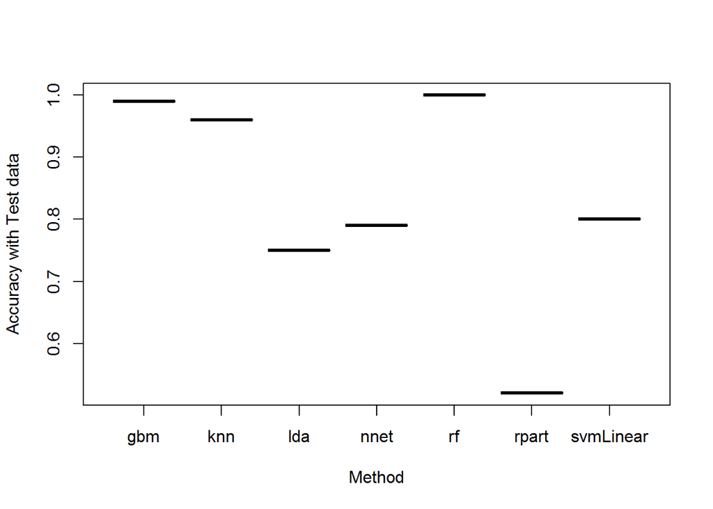

```r
plot(results$Method, results$`Accuracy Test`, xlab="Method", ylab="Accuracy with Test data")
```

Last (and in fact least) we have the traditional classification tree (rpart), which really struggled to achieve accuracy above 50%, rendering it unsuitable for any sort of prediction in combination with the data at hand.

## Prediction and verification

```r
pred.rf    <- predict(fit.rf,    df2.val)
pred.gbm   <- predict(fit.gbm,   df2.val)
pred.knn   <- predict(fit.knn,   df2.val)
pred.svm   <- predict(fit.svm,   df2.val)
pred.nnet  <- predict(fit.nnet,  df2.val)
pred.lda   <- predict(fit.knn,   df2.val)
pred.rpart <- predict(fit.rpart, df2.val)
```

We submitted the predicitions provided by the random forests method and 100% of them were verified as correct, as we had hoped. We therefore set these predictions as the benchmark and check how well the other methods did in this real world scenario.

```r
library(calibrate)
cm2.rpart <- confusionMatrix(pred.rpart, pred.rf)
cm2.nnet <-  confusionMatrix(pred.nnet,  pred.rf)
cm2.svm <-   confusionMatrix(pred.svm,   pred.rf)
cm2.gbm <-   confusionMatrix(pred.gbm,   pred.rf)
cm2.lda <-   confusionMatrix(pred.lda,   pred.rf)
cm2.rf <-    confusionMatrix(pred.rf,    pred.rf)
cm2.knn <-   confusionMatrix(pred.knn,   pred.rf)

results$acc2 <-           (c(cm2.rpart$overall[1]
                           , cm2.nnet$overall[1]
                           , cm2.svm$overall[1]
                           , cm2.gbm$overall[1]
                           , cm2.lda$overall[1]
                           , cm2.rf$overall[1]
                           , cm2.knn$overall[1]
                          ))

names(results) <- c("Method", "Accuracy Test", "Accuracy Eval")
results
```

```
##      Method Accuracy Test Accuracy Eval
## 1     rpart          0.52          0.40
## 2      nnet          0.79          0.85
## 3 svmLinear          0.80          0.80
## 4       gbm          0.99          1.00
## 5       lda          0.75          0.95
## 6        rf          1.00          1.00
## 7       knn          0.96          0.95
```

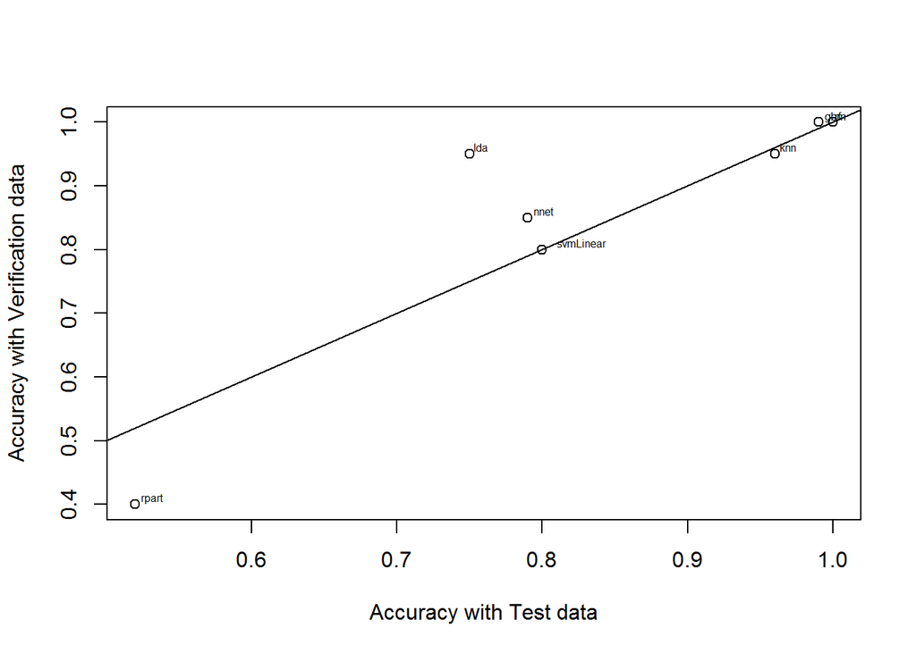

```r
plot(results$`Accuracy Test`, results$`Accuracy Eval`, xlab="Accuracy with Test data", ylab="Accuracy with Verification data")
textxy(results$`Accuracy Test`, results$`Accuracy Eval`, results$Method)
abline(0,1)
```

As can be seen from the plot, there are some interesting differences in performance against the test and the validation data set. For the top performers in the previous section (rf, gbm and knn) the accuracy value has not changed much.